# PRACTICA 2: LIMPIEZA Y VALIDACIÓN DE LOS DATOS

Carles Maggi Gómez - Joan A. Maggi Gómez

3 de junio 2019

Partim de tres fitxers de la primera parts de la pràctica que cal unificar en un sol per poder ser tratats. L’objectiu es verure si hi ha diferencies de quailitat dels hotels en general i després en particular, segons les puntuacions dels comentaris desl usuaris, entre els periodes de hivern (‘primer trimestre’), i estiu(‘tercer trimestre’).

```r
# Lectura del fitxer - read.csv()

categories <-read.csv("https://raw.githubusercontent.com/joanmaggigo/practica2/master/CSV/CategoriesXComentariBooking.csv",header=F,sep=",",encoding = "UTF-8" ,stringsAsFactors = FALSE)
comentaris <-read.csv("https://raw.githubusercontent.com/joanmaggigo/practica2/master/CSV/ComentarisXHotelsBarcelonaBooking.csv",header=F,sep=",",encoding = "UTF-8" ,stringsAsFactors = FALSE)
estancies<-read.csv("https://raw.githubusercontent.com/joanmaggigo/practica2/master/CSV/HotelsBarcelonaBooking.csv",header=F,sep=",",encoding = "UTF-8" ,stringsAsFactors = FALSE)
```

Afegim els noms del atributs.

```r
colnames(estancies)<-c("idHotel","estrelles","nota","nom","link")
colnames(comentaris)<-c("idHotel","idIteracio","index","nomHotel","nota","comPositiu","comNegatiu","data")
colnames(categories)<-c("idHotel","idIteracio","index","Categoria")
```

# 1 Descripcó dels dataset.

Podem trobar el datasets en el següent repositori :

https://github.com/joanmaggigo/practica2/CSV

El dataset d’hotels conté 300 registres i 5 variables. El dataset de comentaris conte 24874 registres i 8 variables. El dataset de categories per comentaries conte 114669 registres i 4 variables.

Comencem donant un cop d’ull al contingut del fitxers :

```r
kable(head(categories,10),caption ="Inspecció visual categories")
```

Inspecció visual categories

| idHotel | idIteracio | index | Categoria |
| --- | --- | --- | --- |
| 90587 | 1 | 1 | Viajedeocio |
| 90587 | 1 | 1 | Pareja |
| 90587 | 1 | 1 | HabitaciónDobleSuperior |
| 90587 | 1 | 1 | Estanciade1noche |
| 90587 | 1 | 1 | Enviadopormóvil |
| 90587 | 1 | 2 | Grupo |
| 90587 | 1 | 2 | HabitaciónDoble-1o2camas |
| 90587 | 1 | 2 | Estanciade3noches |
| 90587 | 1 | 2 | Enviadopormóvil |
| 90587 | 1 | 3 | Viajedenegocios |

A tall d’exemple, veiem que el fitxer de categories té valors com ara ‘Pareja’ o ‘Grupo’ que entenem que són valors possibles dins la categoria d’acompanyament (o tipus d’acompanyament), així com ‘HabitaciónDobleSuperior’ o ‘HabitaciónDoble-1o2camas’, que serien valors de la categoria tipus d’habitació.

Mirem ara el fitxer dels hotels:

```r
# head(estancies[(estancies$estrelles==0),"nom"])
head(estancies,10)
```

```
##    idHotel estrelles nota                                    nom
## 1    90587         3  8,2              Catalonia Sagrada Familia
## 2   770635         0  9,3                             Urquinaona
## 3  1003967         0  7,9           Habitat Apartments Bail<e9>n
## 4   584514         0  8,1              Habitat Apartments Alibei
## 5   584538         0  8,4                My Address in Barcelona
## 6  2934029         0  8,4                            Barceloneta
## 7  1565008         0  7,8           Ronda Sant Pere with Terrace
## 8   291828         0  8,8     You Stylish City Centre Apartments
## 9   730585         0  9,1 Bcn Paseo De Gracia Rocamora Apartment
## 10  579277         0  7,5          AB Paseo de Gracia Apartments
##                                                                                                         link
## 1                      https://www.booking.com/hotel/es/cataloniaaragon.es.html?from=searchresults#hotelTmpl
## 2                      https://www.booking.com/hotel/es/chic-urquinaona.es.html?from=searchresults#hotelTmpl
## 3            https://www.booking.com/hotel/es/habitat-apartments-bailen.es.html?from=searchresults#hotelTmpl
## 4  https://www.booking.com/hotel/es/habitat-apartments-alibei-barcelona.es.html?from=searchresults#hotelTmpl
## 5      https://www.booking.com/hotel/es/modernist-apartment-city-centre.es.html?from=searchresults#hotelTmpl
## 6               https://www.booking.com/hotel/es/barceloneta-barcelona1.es.html?from=searchresults#hotelTmpl
## 7                    https://www.booking.com/hotel/es/ronda-sant-pere-i.es.html?from=searchresults#hotelTmpl
## 8   https://www.booking.com/hotel/es/you-stylish-city-centre-apartments.es.html?from=searchresults#hotelTmpl
## 9         https://www.booking.com/hotel/es/bcn-paseo-de-gracia-aparment.es.html?from=searchresults#hotelTmpl
## 10 https://www.booking.com/hotel/es/apartment-barcelona-paseo-de-gracia.es.html?from=searchresults#hotelTmpl
```

D’altra banda, quan mirem el fitxer d’hotels, veiem que existeixen valors d’estrelles = 0 que mirant el nom de l’hotel veiem que no són hotels, sino que es refereixen a apartaments. Com que nosaltres ens centrarem en els Hotels tindrem que prescindir d’aquests últims.

Començarem a abordar el problema, fent el merge dels datasets, i analitzant el tema de les categories nomes amb els hotels tal i com hem dit, no tenint en compte els apartaments ( Estrelles = 0)

Primer ajuntarem en un sol dataset els comentaris i les categories. Aquest dataset estan relacionats pel “idHotel”,“idIteracio”,“index”, per tant utilitzarem aquet camps fer fusionar-los.

```r
# Creem un única dataset que fusiona tots els comentaries i categories
comentaris.cat<-merge(comentaris,categories,by.x=c("idHotel","idIteracio","index"),by.y=c("idHotel","idIteracio","index"))
```

Tot seguit fusionarem el nou contingut de comentaris amb el hotel. En aquest cas els datsets estan relacionats per “idHotel”. Aprofitem per nomes incloure els que són hotels “estrelless <>0”, tal com hem dit que fariem abans. Al final mirem com ens queda el fitxer

```r
# Fem el merge amb hotels
hotels.comentaris.cat<-merge(comentaris.cat,estancies, by.x="idHotel", by.y="idHotel")
hotels<-hotels.comentaris.cat[which(hotels.comentaris.cat$estrelles!=0),]
kable(head(hotels,10), caption="Hotels Comentaris i Categories")
```

Hotels Comentaris i Categories

|  | idHotel | idIteracio | index | nomHotel | nota.x | comPositiu | comNegatiu | data | Categoria | estrelles | nota.y | nom | link |
| --- | --- | --- | --- | --- | --- | --- | --- | --- | --- | --- | --- | --- | --- |
| 412 | 13651 | 1 | 1 | Atlantis by Atbcn | 8,8 | La ubicación es excelente tiene una buena conexión con las ramblas y la zona universitaria, la habitación es muy amplia, bien equipada y limpia. En general los servicios son excelente | No todo el personal fue amable. El sofá que estaba en la habitación estaba manchado de lo sucio | 2019-04-13 | Viajedenegocios | 3 | 8,7 | Atlantis by Atbcn | https://www.booking.com/hotel/es/atlantis.es.html?from=searchresults#hotelTmpl |
| 413 | 13651 | 1 | 1 | Atlantis by Atbcn | 8,8 | La ubicación es excelente tiene una buena conexión con las ramblas y la zona universitaria, la habitación es muy amplia, bien equipada y limpia. En general los servicios son excelente | No todo el personal fue amable. El sofá que estaba en la habitación estaba manchado de lo sucio | 2019-04-13 | Grupodeamigos | 3 | 8,7 | Atlantis by Atbcn | https://www.booking.com/hotel/es/atlantis.es.html?from=searchresults#hotelTmpl |
| 414 | 13651 | 1 | 1 | Atlantis by Atbcn | 8,8 | La ubicación es excelente tiene una buena conexión con las ramblas y la zona universitaria, la habitación es muy amplia, bien equipada y limpia. En general los servicios son excelente | No todo el personal fue amable. El sofá que estaba en la habitación estaba manchado de lo sucio | 2019-04-13 | HabitaciónDoble-2camas | 3 | 8,7 | Atlantis by Atbcn | https://www.booking.com/hotel/es/atlantis.es.html?from=searchresults#hotelTmpl |
| 415 | 13651 | 1 | 1 | Atlantis by Atbcn | 8,8 | La ubicación es excelente tiene una buena conexión con las ramblas y la zona universitaria, la habitación es muy amplia, bien equipada y limpia. En general los servicios son excelente | No todo el personal fue amable. El sofá que estaba en la habitación estaba manchado de lo sucio | 2019-04-13 | Estanciade1noche | 3 | 8,7 | Atlantis by Atbcn | https://www.booking.com/hotel/es/atlantis.es.html?from=searchresults#hotelTmpl |
| 416 | 13651 | 1 | 1 | Atlantis by Atbcn | 8,8 | La ubicación es excelente tiene una buena conexión con las ramblas y la zona universitaria, la habitación es muy amplia, bien equipada y limpia. En general los servicios son excelente | No todo el personal fue amable. El sofá que estaba en la habitación estaba manchado de lo sucio | 2019-04-13 | Enviadopormóvil | 3 | 8,7 | Atlantis by Atbcn | https://www.booking.com/hotel/es/atlantis.es.html?from=searchresults#hotelTmpl |
| 417 | 13651 | 1 | 10 | Atlantis by Atbcn | 9,2 | Siempre que he ido, me ha encantado. Te hacen sentir, casi, casi, como en casa. | Ruido de motor o alguna máquina antes de las siete de la mañana. A parte de esto, todo fue perfecto. | 2019-01-30 | Viajedeocio | 3 | 8,7 | Atlantis by Atbcn | https://www.booking.com/hotel/es/atlantis.es.html?from=searchresults#hotelTmpl |
| 418 | 13651 | 1 | 10 | Atlantis by Atbcn | 9,2 | Siempre que he ido, me ha encantado. Te hacen sentir, casi, casi, como en casa. | Ruido de motor o alguna máquina antes de las siete de la mañana. A parte de esto, todo fue perfecto. | 2019-01-30 | Pareja | 3 | 8,7 | Atlantis by Atbcn | https://www.booking.com/hotel/es/atlantis.es.html?from=searchresults#hotelTmpl |
| 419 | 13651 | 1 | 10 | Atlantis by Atbcn | 9,2 | Siempre que he ido, me ha encantado. Te hacen sentir, casi, casi, como en casa. | Ruido de motor o alguna máquina antes de las siete de la mañana. A parte de esto, todo fue perfecto. | 2019-01-30 | HabitaciónDoble-2camas | 3 | 8,7 | Atlantis by Atbcn | https://www.booking.com/hotel/es/atlantis.es.html?from=searchresults#hotelTmpl |
| 420 | 13651 | 1 | 10 | Atlantis by Atbcn | 9,2 | Siempre que he ido, me ha encantado. Te hacen sentir, casi, casi, como en casa. | Ruido de motor o alguna máquina antes de las siete de la mañana. A parte de esto, todo fue perfecto. | 2019-01-30 | Estanciade1noche | 3 | 8,7 | Atlantis by Atbcn | https://www.booking.com/hotel/es/atlantis.es.html?from=searchresults#hotelTmpl |
| 421 | 13651 | 1 | 11 | Atlantis by Atbcn | 10 | Acogedor, limpio, muy bien situado, sencillo y elegante…¡Muy recomendable! Y excelente desayuno… | Un leve - pero subsanable - ruido en una rejilla de ventilación, habitación 401. | 2019-01-20 | Viajedenegocios | 3 | 8,7 | Atlantis by Atbcn | https://www.booking.com/hotel/es/atlantis.es.html?from=searchresults#hotelTmpl |

```r
#Veiem, per descripció de dataset que el identificador de la persona/comentari es la concateniació del idhotel, ititeració i index.
hotels$idPersona <- paste(as.character(hotels$idHotel), as.character(hotels$idIteracio), as.character(hotels$index),sep="_")

#Cada comentari/persona té vinculada n descripcions de categories en el fitxer de categories. Volem veure cuantes descripcions de categories hi ha per cada comentari/persona (i el seu volumen) per poder saber sota quins conceptes s'agrupen les categories.
categoria_per_comentari <- hotels %>% group_by(idPersona) %>% summarize(total_cat=n())
comentaris_per_num_categories<-categoria_per_comentari %>% group_by(total_cat) %>% summarize(total_comentaris=n())
kable(comentaris_per_num_categories, caption="Distribució de total Valors categories per comentaris")
```

Distribució de total Valors categories per comentaris

| total_cat | total_comentaris |
| --- | --- |
| 2 | 4 |
| 3 | 465 |
| 4 | 5446 |
| 5 | 10352 |
| 6 | 17 |

En primer lloc vam pensar en agrupar només en 5 categories, tenint en compte que el comentaris que en tenen 6 eren pocs i ens semblaven irrellevants.Finalment, ens hem adonat que això tenia efectes sobre altres comentaris perquè ens hem trobat que per un mateixa categoria en un comentari hi havia dos valors possibles, pel que el primer procés d’agrupació ha sigut erroni i hem detectat on teniem l’error. L’error era sobre el valor “AmbMascota” que l’haviem considerat inicialment com tipus de companyia però era un element diferenciat. Per veure-ho clar, fem una selecció dels comentaris que tene 6 descripcions de la categoria i explorem visualment el contingut.

```r
idpersona_6categories<-unique(categoria_per_comentari[categoria_per_comentari$total_cat==6,"idPersona"])
kable(head(hotels[(hotels$idPersona %in% idpersona_6categories$idPersona ),][c("idPersona","Categoria")],20))
```

|  | idPersona | Categoria |
| --- | --- | --- |
| 8157 | 90039_2_17 | Conunamascota |
| 8158 | 90039_2_17 | Viajedeocio |
| 8159 | 90039_2_17 | Familiaconniñospequeños |
| 8160 | 90039_2_17 | HabitaciónDobleSuperior-1o2camas |
| 8161 | 90039_2_17 | Estanciade1noche |
| 8162 | 90039_2_17 | Enviadopormóvil |
| 8163 | 90039_2_18 | Conunamascota |
| 8164 | 90039_2_18 | Viajedeocio |
| 8165 | 90039_2_18 | Pareja |
| 8166 | 90039_2_18 | HabitaciónDobleExecutive-1o2camas |
| 8167 | 90039_2_18 | Estanciade4noches |
| 8168 | 90039_2_18 | Enviadopormóvil |
| 16103 | 90583_3_33 | Conunamascota |
| 16104 | 90583_3_33 | Viajedeocio |
| 16105 | 90583_3_33 | Pareja |
| 16106 | 90583_3_33 | HabitaciónDoble-1o2camas |
| 16107 | 90583_3_33 | Estanciade1noche |
| 16108 | 90583_3_33 | Enviadopormóvil |
| 16297 | 90586_1_25 | Conunamascota |
| 16298 | 90586_1_25 | Viajedeocio |

Estudiant visualment les descripcions de les categories pensem que podem agrupar en 6 grups. veiem valors que podrien respondre a les categories: Nits,ProcedenciaComentari,Habitació,TipusdeViatge,Acompanyament,ViatjeAmbMascota

```r
#Estudiem el nombre de comentaris agrupats per categoria per començar a definir els tipus de categoria.

kable(head(hotels %>% group_by(Categoria) %>% summarize(total_cat=n()) %>% arrange(desc(total_cat)),10))
```

| Categoria | total_cat |
| --- | --- |
| Viajedeocio | 12546 |
| Enviadopormóvil | 11538 |
| Pareja | 7875 |
| Estanciade1noche | 6155 |
| HabitaciónDoble-1o2camas | 5274 |
| Estanciade2noches | 4203 |
| Personaqueviajasola | 3261 |
| Estanciade3noches | 3073 |
| Familiaconniñospequeños | 2992 |
| Viajedenegocios | 2098 |

En funció de volum comencem a veure patrons per tal de poder crear l’agrupació de la categoria

## 1.1 Creació noves varaibles agrupacio_categoria, id_persona

```r
# Inicialitzem agrupacio_catgoria  amb el valor "Acompanyament" i anirem posant els difertns valors segons el contingut de la "Categoria"
hotels$agrupacio_categoria<-"Acompanyament"
hotels[grep("stancia",hotels$Categoria),"agrupacio_categoria"]<-"Nits"
hotels[grep("Enviadopormóvil",hotels$Categoria),"agrupacio_categoria"]<-"ProcedenciaComentari"
hotels[grep("abitaci",hotels$Categoria),"agrupacio_categoria"]<-"Habitacio"
hotels[grep("uite",hotels$Categoria),"agrupacio_categoria"]<-"Habitacio"
hotels[grep("DobleEstándar",hotels$Categoria),"agrupacio_categoria"]<-"Habitacio"
hotels[grep("Apartamento",hotels$Categoria),"agrupacio_categoria"]<-"Habitacio"
hotels[grep("Viaje",hotels$Categoria),"agrupacio_categoria"]<-"TipusViatge"
hotels[grep("mascota",hotels$Categoria),"agrupacio_categoria"]<-"ViajaConMascota"

# Visualització de tots els grups de categrioes.

agrupacio_categoria<-unique(hotels$agrupacio_categoria)
for (cols in agrupacio_categoria)
{
  aux<-hotels[which(hotels$agrupacio_categoria==cols),]
  aux2<-aux %>% group_by(Categoria) %>% summarize(total_cat=n())
  print(kable(head(aux2,5), caption=as.character(cols)))
}
```

```
##
##
## Table: TipusViatge
##
## Categoria          total_cat
## ----------------  ----------
## Viajedenegocios         2098
## Viajedeocio            12546
##
##
## Table: Acompanyament
##
## Categoria                  total_cat
## ------------------------  ----------
## Familiaconniñosmayores             2
## Familiaconniñospequeños         2992
## Grupo                           1732
## Grupodeamigos                    422
## Pareja                          7875
##
##
## Table: Habitacio
##
## Categoria                    total_cat
## --------------------------  ----------
## 10habitaciones                       1
## 2habitaciones                      239
## 3habitaciones                        9
## ApartamentoConfort                  16
## Apartamentode2dormitorios            1
##
##
## Table: Nits
##
## Categoria             total_cat
## -------------------  ----------
## Estanciade10noches           10
## Estanciade11noches            9
## Estanciade12noches            6
## Estanciade13noches            5
## Estanciade14noches            5
##
##
## Table: ProcedenciaComentari
##
## Categoria          total_cat
## ----------------  ----------
## Enviadopormóvil        11538
##
##
## Table: ViajaConMascota
##
## Categoria        total_cat
## --------------  ----------
## Conunamascota           31
```

Veiem que en el cas de l’agrupació que ens explica el tipus d’habitació i el nombre de nits és interesant recategoritzar la variable, per què hi ha mases valors possibles i alguns amb pocs representats, pel que guanya força sentit.

```r
#Recategoritzem dues agrupacions de categories, en funció dels valors observats. Seran l'agrupació Habitació, y la agrupació Nits

hotels$ReCategoria<-hotels$Categoria
#A les estancies de mes de 7 dies diem que la nova categoria es mésde7dies
hotels$nits<-as.numeric(gsub("\\D", "",hotels$Categoria))
hotels[which(hotels$agrupacio_categoria!="Nits"),"nits"]<-NaN

hotels[which(hotels$agrupacio_categoria=="Nits" & as.numeric(gsub("\\D", "",hotels$Categoria))==1 ) ,"ReCategoria"]<-"Una Nit"
hotels[which(hotels$agrupacio_categoria=="Nits" & as.numeric(gsub("\\D", "",hotels$Categoria))== 2),"ReCategoria"]<-"Dos nits"
hotels[which(hotels$agrupacio_categoria=="Nits" & (as.numeric(gsub("\\D", "",hotels$Categoria))> 2) & as.numeric(gsub("\\D", "",hotels$Categoria))< 6 ) ,"ReCategoria"]<-"De 3 a 5 Nits"
hotels[which(hotels$agrupacio_categoria=="Nits" & (as.numeric(gsub("\\D", "",hotels$Categoria))> 6) & as.numeric(gsub("\\D", "",hotels$Categoria))< 8 ) ,"ReCategoria"]<-"De 6 a 7 Nits"
hotels[which(hotels$agrupacio_categoria=="Nits" & as.numeric(gsub("\\D", "",hotels$Categoria))>7) ,"ReCategoria"]<-"Mesde7"


hotels[which(hotels$agrupacio_categoria=="Habitacio"),"ReCategoria"]<-"Altres"
hotels[hotels$agrupacio_categoria=="Habitacio" & grepl("oble",hotels$Categoria),"ReCategoria"]<-"Habitacio Doble"
hotels[hotels$agrupacio_categoria=="Habitacio" & grepl("ndividual",hotels$Categoria),"ReCategoria"]<-"Habitacio Individual"
hotels[hotels$agrupacio_categoria=="Habitacio" & grepl("uite",hotels$Categoria),"ReCategoria"]<-"Suite"
hotels[hotels$agrupacio_categoria=="Habitacio" & grepl("riple",hotels$Categoria),"ReCategoria"]<-"Habitacio Triple"
hotels[hotels$agrupacio_categoria=="Habitacio" & grepl("druple",hotels$Categoria),"ReCategoria"]<-"Habitacio quadruple"

hotels.Habitacio<-hotels[hotels$agrupacio_categoria=="Habitacio",]
hotels.Habitacio$ReCategoria<-as.factor(hotels.Habitacio$ReCategoria)

agrupacio_categoria_habitacion<-unique(hotels.Habitacio$ReCategoria)
for (cols in agrupacio_categoria_habitacion)
{
print(head(hotels.Habitacio[which(hotels.Habitacio$ReCategoria==cols),] %>% group_by(Categoria) %>% summarize(total_cat=n()),10))
}
```

```
## # A tibble: 10 x 2
##    Categoria                                            total_cat
##    <chr>                                                    <int>
##  1 DobleEstándar                                                1
##  2 Habitaciónconcamadobleoextragrandeyvistaspanorámicas         5
##  3 HabitaciónDoble                                           1189
##  4 HabitaciónDoble-1o2camas                                  5274
##  5 HabitaciónDoble-2camas                                    1248
##  6 HabitaciónDoble(1-2adultos)                                 25
##  7 HabitaciónDoble(1adulto)-1o2camas                            4
##  8 HabitaciónDoble(2adultos)                                  128
##  9 HabitaciónDoble(2adultos+1niño)                             38
## 10 HabitaciónDoble2camasconvistasalapiscina                     3
## # A tibble: 10 x 2
##    Categoria                              total_cat
```

[output cut: 54 more lines]

## 1.2 Creació del Dataset de treball

```r
#Anem a crear el Dataset de treball

#Creem un identificador de persona
categories_per_persona<-hotels %>% group_by(idPersona) %>% summarize(total_cat=n())

#Creem el dataset de treball
data<-unique(hotels[c("nomHotel","nota.x","data","estrelles","idPersona","nota.y")])
data<-merge(data,categories_per_persona,by.x="idPersona",by.y="idPersona")

#Creem un dataset que ajunti el idcomentari amb l'agrupació de categoria
data.Habitacio<-hotels[hotels$agrupacio_categoria=="Habitacio",]
data.Habitacio<-data.Habitacio[c("idPersona","ReCategoria")]
data.Nits<-hotels[hotels$agrupacio_categoria=="Nits",]
data.Nits<-data.Nits[c("idPersona","ReCategoria")]
data.ProcedenciaComentari<-hotels[hotels$agrupacio_categoria=="ProcedenciaComentari",]
data.ProcedenciaComentari<-data.ProcedenciaComentari[c("idPersona","ReCategoria")]
data.TipusViatge<-hotels[hotels$agrupacio_categoria=="TipusViatge",]
data.TipusViatge<-data.TipusViatge[c("idPersona","ReCategoria")]
data.Acompanyament<-hotels[hotels$agrupacio_categoria=="Acompanyament",]
data.Acompanyament<-data.Acompanyament[c("idPersona","ReCategoria")]
data.ViajaConMascota<-hotels[hotels$agrupacio_categoria=="ViajaConMascota",]
data.ViajaConMascota<-data.ViajaConMascota[c("idPersona","ReCategoria")]

#fem els merges per crear el ddataset de treball
data<-merge(data,data.Habitacio,by.x="idPersona",by.y="idPersona",all.x = T)
data<-merge(data,data.Nits,by.x="idPersona",by.y="idPersona",all.x = T)
data<-merge(data,data.ProcedenciaComentari,by.x="idPersona",by.y="idPersona",all.x = T)
data<-merge(data,data.TipusViatge,by.x="idPersona",by.y="idPersona",all.x = T)
data<-merge(data,data.Acompanyament,by.x="idPersona",by.y="idPersona",all.x = T)
data<-merge(data,data.ViajaConMascota,by.x="idPersona",by.y="idPersona",all.x = T)


colnames(data)<-c("idPersona","nomHotel","notapersona","data","estrelles","notaHotel","num_cat","TipusHabitacio","Nits","ProcedenciaComentari","TipusViatge","Acompanyament","ViajaConMascota")
summary(data)
```

```
##   idPersona           nomHotel         notapersona
##  Length:16284       Length:16284       Length:16284
##  Class :character   Class :character   Class :character
##  Mode  :character   Mode  :character   Mode  :character
##
##
##
##      data             estrelles     notaHotel            num_cat
##  Length:16284       Min.   :1.00   Length:16284       Min.   :2.000
##  Class :character   1st Qu.:2.00   Class :character   1st Qu.:4.000
##  Mode  :character   Median :3.00   Mode  :character   Median :5.000
##                     Mean   :3.11                      Mean   :4.609
##                     3rd Qu.:4.00                      3rd Qu.:5.000
##                     Max.   :5.00                      Max.   :6.000
##  TipusHabitacio         Nits           ProcedenciaComentari
##  Length:16284       Length:16284       Length:16284
##  Class :character   Class :character   Class :character
##  Mode  :character   Mode  :character   Mode  :character
##
##
##
##  TipusViatge        Acompanyament      ViajaConMascota
##  Length:16284       Length:16284       Length:16284
##  Class :character   Class :character   Class :character
##  Mode  :character   Mode  :character   Mode  :character
##
##
##
```

# 2 Neteja de dades

## 2.1 Tipus de dades

Assignem el tipus de dades correcte, ja que les notes tenen una ‘,’ com a separador decimal i cal posar-hi un punt, i la data l’hem de passar com a tipus data.

```r
data <- select(data, -idPersona)
```

```r
#Veiem que s'ha de passar la nota del hotel a numèric
data$notaHotel<-as.numeric(gsub(",",".",data$notaHotel))
#veiem que s'ha de passar les notes de persona  a numeric
data$notapersona<-as.numeric(gsub(",",".",data$notapersona))
#Hem de posar la data en format data
data$data<-as.Date(data$data)
summary(data)
```

```
##    nomHotel          notapersona          data              estrelles
##  Length:16284       Min.   : 2.500   Min.   :2017-04-13   Min.   :1.00
##  Class :character   1st Qu.: 7.500   1st Qu.:2017-11-25   1st Qu.:2.00
##  Mode  :character   Median : 8.800   Median :2018-05-13   Median :3.00
##                     Mean   : 8.558   Mean   :2018-05-06   Mean   :3.11
##                     3rd Qu.:10.000   3rd Qu.:2018-11-04   3rd Qu.:4.00
##                     Max.   :10.000   Max.   :2019-04-13   Max.   :5.00
##    notaHotel        num_cat      TipusHabitacio         Nits
##  Min.   :7.900   Min.   :2.000   Length:16284       Length:16284
##  1st Qu.:8.300   1st Qu.:4.000   Class :character   Class :character
##  Median :8.500   Median :5.000   Mode  :character   Mode  :character
##  Mean   :8.535   Mean   :4.609
##  3rd Qu.:8.700   3rd Qu.:5.000
##  Max.   :9.400   Max.   :6.000
##  ProcedenciaComentari TipusViatge        Acompanyament
##  Length:16284         Length:16284       Length:16284
##  Class :character     Class :character   Class :character
##  Mode  :character     Mode  :character   Mode  :character
##
##
##
##  ViajaConMascota
##  Length:16284
##  Class :character
##  Mode  :character
##
##
##
```

## 2.2 Eliminacó si cal de valors outliers i fringeliers

Mirarem els valors 0 de les notes mitjana d’hotel i les notes de les persons. Recordem que el valor 0 en les estrelles hem entés que significava que era un apartament i per tant no entra en el nostre estudi, ara mirem les notes mitja dels hotels i la nota de les persones.

Eliminem els registres que sobrepassen 3 desviacions estandars la nota donada per les persones.Ho fem a nivell d’hotel, i no pas a nivell general, perquè entenem que si un hotel és molt dolent potser tothom el puntua amb 1 o 2, que de segur serien outliers si els considressim en la totalitat de les puntuacions de tots els hotels, pero serien valors força normals a la puntuació própia del hotel.

```r
summary(data)
```

```
##    nomHotel          notapersona          data              estrelles
##  Length:16284       Min.   : 2.500   Min.   :2017-04-13   Min.   :1.00
##  Class :character   1st Qu.: 7.500   1st Qu.:2017-11-25   1st Qu.:2.00
##  Mode  :character   Median : 8.800   Median :2018-05-13   Median :3.00
##                     Mean   : 8.558   Mean   :2018-05-06   Mean   :3.11
##                     3rd Qu.:10.000   3rd Qu.:2018-11-04   3rd Qu.:4.00
##                     Max.   :10.000   Max.   :2019-04-13   Max.   :5.00
##    notaHotel        num_cat      TipusHabitacio         Nits
##  Min.   :7.900   Min.   :2.000   Length:16284       Length:16284
##  1st Qu.:8.300   1st Qu.:4.000   Class :character   Class :character
##  Median :8.500   Median :5.000   Mode  :character   Mode  :character
##  Mean   :8.535   Mean   :4.609
##  3rd Qu.:8.700   3rd Qu.:5.000
##  Max.   :9.400   Max.   :6.000
##  ProcedenciaComentari TipusViatge        Acompanyament
##  Length:16284         Length:16284       Length:16284
##  Class :character     Class :character   Class :character
##  Mode  :character     Mode  :character   Mode  :character
##
##
##
##  ViajaConMascota
##  Length:16284
##  Class :character
##  Mode  :character
##
##
##
```

```r
dataaux<-data
noudata <- data.frame(Doubles=double(),
                 Ints=integer(),
                 Factors=factor(),
                 Logicals=logical(),
                 Characters=character(),
                 stringsAsFactors=FALSE)
{
  remove_outliers <- function(x, limit = 3) {
      mn <- mean(x, na.rm = T)
      out <- limit * sd(x, na.rm = T)
      x < (mn - out) | x > (mn + out)
  }
  hotels.outliers<-unique(data$nomHotel)

  for (cols in hotels.outliers){

    un.hotel<-data[data$nomHotel==cols,]

    un.hotel<-un.hotel[remove_outliers(un.hotel$notapersona,3)==FALSE,]
    noudata<-rbind(noudata,un.hotel)
  }
}
hotels.outliers
```

```
##  [1] "Hostal Balkonis"
##  [2] "Atlantis by Atbcn"
##  [3] "Bcn Urban Hotels Gran Rosellon"
##  [4] "Hotel Àmbit Barcelona"
##  [5] "Hotel Turin"
##  [6] "Hotel Arts Barcelona"
##  [7] "Hotel Casa Bonay"
##  [8] "Upper Diagonal"
##  [9] "Negresco Princess 4* Sup"
## [10] "Hotel El Call"
## [11] "Hostal Fernando"
## [12] "The Corner Hotel"
## [13] "Hostal Central Barcelona"
## [14] "Grupotel Gran Via 678"
## [15] "Hostal Benidorm"
```

[output cut: 68 more lines]

```r
summary(noudata)
```

```
##    nomHotel          notapersona          data              estrelles
##  Length:16091       Min.   : 2.500   Min.   :2017-04-13   Min.   :1.00
##  Class :character   1st Qu.: 7.900   1st Qu.:2017-11-25   1st Qu.:2.00
##  Mode  :character   Median : 9.000   Median :2018-05-13   Median :3.00
##                     Mean   : 8.617   Mean   :2018-05-06   Mean   :3.11
##                     3rd Qu.:10.000   3rd Qu.:2018-11-04   3rd Qu.:4.00
##                     Max.   :10.000   Max.   :2019-04-13   Max.   :5.00
##                     NA's   :1        NA's   :1            NA's   :1
##    notaHotel        num_cat      TipusHabitacio         Nits
##  Min.   :8.000   Min.   :2.000   Length:16091       Length:16091
##  1st Qu.:8.300   1st Qu.:4.000   Class :character   Class :character
##  Median :8.500   Median :5.000   Mode  :character   Mode  :character
##  Mean   :8.534   Mean   :4.608
##  3rd Qu.:8.700   3rd Qu.:5.000
##  Max.   :9.400   Max.   :6.000
##  NA's   :1       NA's   :1
##  ProcedenciaComentari TipusViatge        Acompanyament
##  Length:16091         Length:16091       Length:16091
##  Class :character     Class :character   Class :character
##  Mode  :character     Mode  :character   Mode  :character
##
##
##
##
##  ViajaConMascota
##  Length:16091
##  Class :character
##  Mode  :character
##
##
##
##
```

```r
data<-noudata
```

## 2.3 Mirem les gràfiques quantile-quamtile plot i l’histograma per veure si hi ha variables susceptibles a la normalització

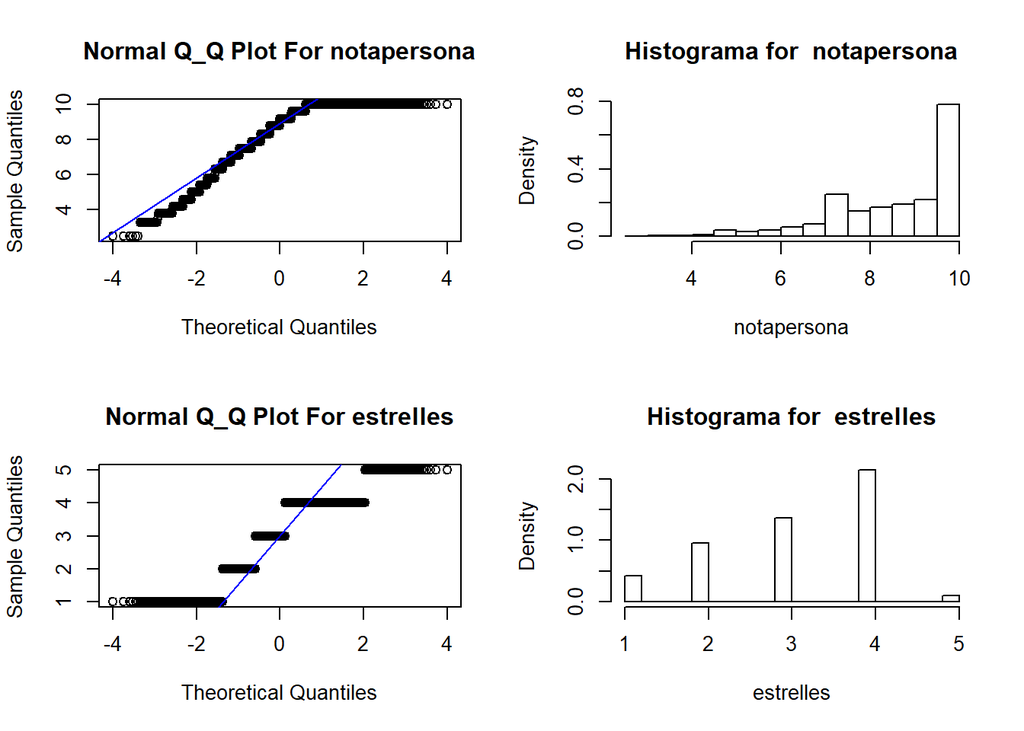

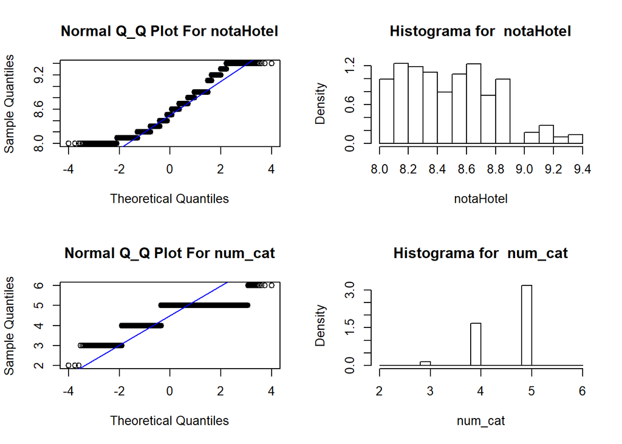

```r
par(mfrow=c(2,2))
for(i in 1:ncol(data)) {
  if (is.numeric(data[,i])){
    qqnorm(data[,i],main=paste("Normal Q_Q Plot For",colnames(data)[i]))
    qqline(data[,i],col="blue")
    hist(data[,i],main=paste("Histograma for ",colnames(data)[i]), xlab=colnames(data)[i],freq=FALSE)
  }
}
```

```r
par(mfrow=c(1,1))
```

```r
#shapiro.test(data$notapersona)
#shapiro.test(data$estrelles)
#shapiro.test(data$notahotel)
```

```r
#Comencem analitzant des de la perspectiva de l'hotel.
aux.hotels<-unique(data[c("nomHotel","notaHotel","estrelles","notapersona")])
summary(aux.hotels)
```

```
##    nomHotel           notaHotel       estrelles     notapersona
##  Length:1209        Min.   :8.000   Min.   :1.00   Min.   : 2.50
##  Class :character   1st Qu.:8.300   1st Qu.:3.00   1st Qu.: 6.30
##  Mode  :character   Median :8.500   Median :4.00   Median : 7.50
##                     Mean   :8.557   Mean   :3.32   Mean   : 7.43
##                     3rd Qu.:8.700   3rd Qu.:4.00   3rd Qu.: 8.80
##                     Max.   :9.400   Max.   :5.00   Max.   :10.00
##                     NA's   :1       NA's   :1      NA's   :1
```

```r
#Pel que fa a les estrelles veiem que té una distribució raonable amb valors, etc.. per tant ho donem per bo

#Les notes mitjes del hotel semblen raonables.

# Anteriorment ja hem eliminat registres que tenien la puntuacio de persona més gran que 3 vegades la desviació estandar, ja que pot ser puntual o molt  subjectiu que hagin tingut una mala experiencia puntual i estiguin resentits,  o be és un error.
```

## 2.4 Tractament dels valors na

```r
#veiem els NA
colSums(is.na(data))
```

```
##             nomHotel          notapersona                 data
##                    1                    1                    1
##            estrelles            notaHotel              num_cat
##                    1                    1                    1
##       TipusHabitacio                 Nits ProcedenciaComentari
##                    8                    8                 4702
##          TipusViatge        Acompanyament      ViajaConMascota
##                 1621                    1                16060
```

```r
#Anem a pams, pel cas, ViajaConMascota, sabem que si no está informat, es raonable pensar que no viatge ambMascota. Fem una recategorització per transformar-ho en una binaria, els que tenen valors S els que no en tenen N

data[!(is.na(data$ViajaConMascota)),"ViajaConMascota"]<-"S"
data[(is.na(data$ViajaConMascota)),"ViajaConMascota"]<-"N"

#Per tipus de viatge, el volum de NA es un 10% aprox, per tant pensem que té prou instancia per si sol com per afegir un valor més dins la categoria que sigui SENSEINFORMAR per veure impactes en la nota (o altres)

data[(is.na(data$TipusViatge)),"TipusViatge"]<-"SenseInformar"

#Procedencia comentari, només té un valor informat, per tant, entenem que l'altre valor és per web
data[(is.na(data$ProcedenciaComentari)),"ProcedenciaComentari"]<-"EnviadoporWeb"

#A tipusHabitacio I Nits, tenim la sospita que els que estan en NA son els mateixos.
data[(is.na(data$Nits)) |is.na(data$TipusHabitacio),]
```

```
##                         nomHotel notapersona       data estrelles
## 1645               Hotel El Call         9.6 2018-01-02         1
## 3215      Golden Tulip Barcelona        10.0 2017-07-30         4
## NA                          <NA>          NA       <NA>        NA
## 7849      Melia Barcelona Sarriá         8.8 2018-08-08         5
## 7878      Melia Barcelona Sarriá         2.5 2018-04-17         5
## 10336 Hesperia Barcelona Del Mar         9.6 2018-08-29         4
## 10892 Tryp Barcelona Apolo Hotel         3.3 2019-02-22         4
## 14135  Pullman Barcelona Skipper        10.0 2019-02-13         5
##       notaHotel num_cat TipusHabitacio Nits ProcedenciaComentari
## 1645        8.3       3           <NA> <NA>      Enviadopormóvil
## 3215        8.7       2           <NA> <NA>        EnviadoporWeb
## NA           NA      NA           <NA> <NA>        EnviadoporWeb
## 7849        8.2       3           <NA> <NA>      Enviadopormóvil
## 7878        8.2       3           <NA> <NA>      Enviadopormóvil
## 10336       8.2       2           <NA> <NA>        EnviadoporWeb
## 10892       8.6       3           <NA> <NA>      Enviadopormóvil
## 14135       8.5       2           <NA> <NA>        EnviadoporWeb
##           TipusViatge           Acompanyament ViajaConMascota
## 1645      Viajedeocio                  Pareja               N
## 3215      Viajedeocio Familiaconniñospequeños               N
## NA      SenseInformar                    <NA>               N
## 7849      Viajedeocio Familiaconniñospequeños               N
## 7878  Viajedenegocios     Personaqueviajasola               N
## 10336     Viajedeocio                   Grupo               N
## 10892 Viajedenegocios     Personaqueviajasola               N
## 14135 Viajedenegocios     Personaqueviajasola               N
```

```r
#Veiem que si per tant, sembla raonable pensar que és un error i que milor obviar la informació (eliminarla)
data<-data[!(is.na(data$Nits)) & !(is.na(data$TipusHabitacio)),]

# VIsualistació del contingut del nostre dataset

summary(data)
```

```
##    nomHotel          notapersona          data              estrelles
##  Length:16083       Min.   : 2.500   Min.   :2017-04-13   Min.   :1.00
##  Class :character   1st Qu.: 7.900   1st Qu.:2017-11-25   1st Qu.:2.00
##  Mode  :character   Median : 9.000   Median :2018-05-13   Median :3.00
##                     Mean   : 8.617   Mean   :2018-05-06   Mean   :3.11
##                     3rd Qu.:10.000   3rd Qu.:2018-11-04   3rd Qu.:4.00
##                     Max.   :10.000   Max.   :2019-04-13   Max.   :5.00
##    notaHotel        num_cat      TipusHabitacio         Nits
##  Min.   :8.000   Min.   :3.000   Length:16083       Length:16083
##  1st Qu.:8.300   1st Qu.:4.000   Class :character   Class :character
##  Median :8.500   Median :5.000   Mode  :character   Mode  :character
##  Mean   :8.534   Mean   :4.609
##  3rd Qu.:8.700   3rd Qu.:5.000
##  Max.   :9.400   Max.   :6.000
##  ProcedenciaComentari TipusViatge        Acompanyament
##  Length:16083         Length:16083       Length:16083
##  Class :character     Class :character   Class :character
##  Mode  :character     Mode  :character   Mode  :character
##
##
##
##  ViajaConMascota
##  Length:16083
##  Class :character
##  Mode  :character
##
##
##
```

## 2.5 Factorització de variables categòriques

```r
#Anem a transformar les variables categóriques as.factor
data$ViajaConMascota<-as.factor(data$ViajaConMascota)
data$Acompanyament<-as.factor(data$Acompanyament)
data$TipusViatge<-as.factor(data$TipusViatge)
data$ProcedenciaComentari<-as.factor(data$ProcedenciaComentari)
data$Nits<-as.factor(data$Nits)
data$TipusHabitacio<-as.factor(data$TipusHabitacio)
data$estrelles<-as.factor(data$estrelles)

# En el cas de estrelles , els hi donem un ordre, ja que la qualificació és el que indica.
data$estrelles<-ordered(data$estrelles,levels=c("1","2","3","4","5"))
data$nomHotel<-as.factor(data$nomHotel)
summary(data)
```

```
##                               nomHotel      notapersona
##  Catalonia Sagrada Familia        :  911   Min.   : 2.500
##  Hotel Lloret Ramblas             :  834   1st Qu.: 7.900
##  Ayre Hotel Gran Vía              :  775   Median : 9.000
##  Barceló Sants                    :  627   Mean   : 8.617
##  Hotel Cortes                     :  540   3rd Qu.:10.000
##  NH Collection Barcelona Constanza:  463   Max.   :10.000
##  (Other)                          :11933
##       data            estrelles   notaHotel        num_cat
##  Min.   :2017-04-13   1:1364    Min.   :8.000   Min.   :3.000
##  1st Qu.:2017-11-25   2:3068    1st Qu.:8.300   1st Qu.:4.000
##  Median :2018-05-13   3:4415    Median :8.500   Median :5.000
##  Mean   :2018-05-06   4:6906    Mean   :8.534   Mean   :4.609
##  3rd Qu.:2018-11-04   5: 330    3rd Qu.:8.700   3rd Qu.:5.000
##  Max.   :2019-04-13             Max.   :9.400   Max.   :6.000
##
##               TipusHabitacio                 Nits
##  Altres              : 1166   De 3 a 5 Nits    :5338
##  Habitacio Doble     :12511   De 6 a 7 Nits    : 133
##  Habitacio Individual: 1411   Dos nits         :4146
##  Habitacio quadruple :  199   Estanciade6noches: 286
##  Habitacio Triple    :  678   Mesde7           : 109
##  Suite               :  118   Una Nit          :6071
##
##       ProcedenciaComentari          TipusViatge
##  Enviadopormóvil:11385     SenseInformar  : 1620
##  EnviadoporWeb  : 4698     Viajedenegocios: 2066
##                            Viajedeocio    :12397
##
##
##
##
##                  Acompanyament  ViajaConMascota
##  Familiaconniñosmayores :   2   N:16052
##  Familiaconniñospequeños:2961   S:   31
##  Grupo                  :1711
##  Grupodeamigos          : 419
##  Pareja                 :7781
##  Personaqueviajasola    :3209
##
```

```r
#Ens adonem que acompanyament te un factor que es 'Familia con niños mayores' i 'Familia con ninos pequeños', i el grup de 'Familia con niños mayores' es força petit, pel que agrupem els dos nivells a 'Familiaconniños'
levels(data$Acompanyament) <- c("Familiaconniños","Familiaconniños","Grupo","Grupodeamigos","Pareja","Personaqueviajasola")
```

## 2.6 Nous atributs

Ens decidim ara a fer les primeres hipotesis, i la primera és que volem saber si les notes que es donen en el primer trimestre de l’any son diferents a les que es donen a l’estiu

Per això, caldrà, que afegim una variable nova, que determini l’epoca de l’any en funció de la data del comentari (pot haver-hi un decalatge de dies, però assumin que els comentaris es fan aprop de la data en la que s’ha gaudit l’estancia de l’hotel)

```r
data$Season<-"PRIMER TRIMESTRE"
data[month(data$data)>=4 & month(data$data)<=6,"Season" ]<-"SEGON TRIMESTRE"
data[month(data$data)>=7 & month(data$data)<=9,"Season" ]<-"TERCER TRIMESTRE"
data[month(data$data)>=10 & month(data$data)<=12,"Season" ]<-"QUART TRIMESTRE"
data$Season<-as.factor(data$Season)
summary(data)
```

```
##                               nomHotel      notapersona
##  Catalonia Sagrada Familia        :  911   Min.   : 2.500
##  Hotel Lloret Ramblas             :  834   1st Qu.: 7.900
##  Ayre Hotel Gran Vía              :  775   Median : 9.000
##  Barceló Sants                    :  627   Mean   : 8.617
##  Hotel Cortes                     :  540   3rd Qu.:10.000
##  NH Collection Barcelona Constanza:  463   Max.   :10.000
##  (Other)                          :11933
##       data            estrelles   notaHotel        num_cat
##  Min.   :2017-04-13   1:1364    Min.   :8.000   Min.   :3.000
##  1st Qu.:2017-11-25   2:3068    1st Qu.:8.300   1st Qu.:4.000
##  Median :2018-05-13   3:4415    Median :8.500   Median :5.000
##  Mean   :2018-05-06   4:6906    Mean   :8.534   Mean   :4.609
##  3rd Qu.:2018-11-04   5: 330    3rd Qu.:8.700   3rd Qu.:5.000
##  Max.   :2019-04-13             Max.   :9.400   Max.   :6.000
##
##               TipusHabitacio                 Nits
##  Altres              : 1166   De 3 a 5 Nits    :5338
##  Habitacio Doble     :12511   De 6 a 7 Nits    : 133
##  Habitacio Individual: 1411   Dos nits         :4146
##  Habitacio quadruple :  199   Estanciade6noches: 286
##  Habitacio Triple    :  678   Mesde7           : 109
##  Suite               :  118   Una Nit          :6071
##
##       ProcedenciaComentari          TipusViatge
##  Enviadopormóvil:11385     SenseInformar  : 1620
##  EnviadoporWeb  : 4698     Viajedenegocios: 2066
##                            Viajedeocio    :12397
##
##
##
##
##              Acompanyament  ViajaConMascota              Season
##  Familiaconniños    :2963   N:16052         PRIMER TRIMESTRE:4428
##  Grupo              :1711   S:   31         QUART TRIMESTRE :4079
##  Grupodeamigos      : 419                   SEGON TRIMESTRE :3770
##  Pareja             :7781                   TERCER TRIMESTRE:3806
##  Personaqueviajasola:3209
##
##
```

```r
#Anem a veure si la diferencia en general de les notes de les persones pels hotels difereix entre el primer trimestre i el tercer trimetre. Per això, apliquem un anova.
hotels_1er_3er<-data %>% filter(Season=='PRIMER TRIMESTRE' | Season=='TERCER TRIMESTRE')
aov.hotels_1er_3er=aov(notapersona~Season,hotels_1er_3er)
summary(aov.hotels_1er_3er)
```

```
##               Df Sum Sq Mean Sq F value   Pr(>F)
## Season         1    120  119.55   61.21 5.77e-15 ***
## Residuals   8232  16078    1.95
## ---
## Signif. codes:  0 '***' 0.001 '**' 0.01 '*' 0.05 '.' 0.1 ' ' 1
```

```r
kable(hotels_1er_3er%>% group_by(Season) %>% summarise(n=n(),mean=mean(notapersona),sd=sd(notapersona)))
```

| Season | n | mean | sd |
| --- | --- | --- | --- |
| PRIMER TRIMESTRE | 4428 | 8.733695 | 1.349286 |
| TERCER TRIMESTRE | 3806 | 8.492013 | 1.451689 |

Existeix una forta evidència de diferència de les mitjanes de les notes entre el primer trimestre i el tercer. Sembla ser que cap a l’estiu la qualitat es percebuda pitjor que a l’hivern. Això vol dir o que els clients són més exigents o el personal té menys qualitat.

Ara volem veure, d’aquells hotels que tinguin una mostra superior a 30 tant per l’estiu com per l’hivern tenen una nota significativament diferent entre els dos trimestres.

```r
#busco els hotels que tinguin com a minim 30 elements tant en el primer trimestre com en el tercer.
hotels_comparables<-data %>% group_by(nomHotel,Season)  %>% filter(Season=='PRIMER TRIMESTRE' | Season=='TERCER TRIMESTRE') %>% summarise(n=n()) %>% filter(n>30) %>% group_by(nomHotel) %>% summarise(n=n()) %>% filter(n==2)
data.hotels_comparables <- data[data$nomHotel %in% hotels_comparables$nomHotel,]
data.hotels_comparables<-data.hotels_comparables %>% filter(Season=='PRIMER TRIMESTRE' | Season=='TERCER TRIMESTRE')

#Anem a fer anova hotel per hotel i creant el resultat en forma de taula
llista_hotels=unique(data.hotels_comparables$nomHotel)
result_aov<-NULL
for (cols in llista_hotels)
{
  hotel_actual<-data.hotels_comparables[data.hotels_comparables$nomHotel==cols,]
  aov.hotel_actual=aov(notapersona~Season,hotel_actual)
  if (is.null(result_aov))
  {
    aux<-hotel_actual %>% group_by(nomHotel,Season) %>% summarise(n=n(),mean=mean(notapersona),sd=sd(notapersona))
    aux.1<-aux[aux$Season=='PRIMER TRIMESTRE',]
    aux.2<-aux[aux$Season=='TERCER TRIMESTRE',]
    aux.merge<-merge(aux.1,aux.2,by.x=c("nomHotel"),by.y=c("nomHotel"))
    result_aov<-cbind(aux.merge,cols,summary(aov.hotel_actual)[[1]][["Pr(>F)"]][1])
  }
  else
  {
    aux<-hotel_actual %>% group_by(nomHotel,Season) %>% summarise(n=n(),mean=mean(notapersona),sd=sd(notapersona))
    aux.1<-aux[aux$Season=='PRIMER TRIMESTRE',]
    aux.2<-aux[aux$Season=='TERCER TRIMESTRE',]
    aux.merge<-merge(aux.1,aux.2,by.x=c("nomHotel"),by.y=c("nomHotel"))
    aux.merge<-cbind(aux.merge,cols,summary(aov.hotel_actual)[[1]][["Pr(>F)"]][1])
    result_aov<-rbind(result_aov,aux.merge)
  }
}

result_aov$diferenciaNota<-FALSE
result_aov[(result_aov$`summary(aov.hotel_actual)[[1]][["Pr(>F)"]][1]`<0.05),"diferenciaNota"]<-TRUE
result_aov$diferencia<-result_aov$mean.x-result_aov$mean.y
kable(result_aov)
```

| nomHotel | Season.x | n.x | mean.x | sd.x | Season.y | n.y | mean.y | sd.y | cols | summary(aov.hotel_actual)[[1]][[“Pr(>F)”]][1] | diferenciaNota | diferencia |
| --- | --- | --- | --- | --- | --- | --- | --- | --- | --- | --- | --- | --- |
| Atlantis by Atbcn | PRIMER TRIMESTRE | 69 | 8.879710 | 1.1141575 | TERCER TRIMESTRE | 78 | 8.797436 | 0.9559077 | Atlantis by Atbcn | 0.6306356 | FALSE | 0.0822742 |
| Bcn Urban Hotels Gran Rosellon | PRIMER TRIMESTRE | 74 | 8.571622 | 1.4409396 | TERCER TRIMESTRE | 50 | 8.128000 | 1.5141563 | Bcn Urban Hotels Gran Rosellon | 0.1020065 | FALSE | 0.4436216 |
| Upper Diagonal | PRIMER TRIMESTRE | 33 | 9.130303 | 1.2885275 | TERCER TRIMESTRE | 42 | 8.969048 | 0.9991431 | Upper Diagonal | 0.5432973 | FALSE | 0.1612554 |
| Hostal Fernando | PRIMER TRIMESTRE | 118 | 8.738983 | 1.2965460 | TERCER TRIMESTRE | 81 | 8.370370 | 1.2641642 | Hostal Fernando | 0.0479331 | TRUE | 0.3686127 |
| Grupotel Gran Via 678 | PRIMER TRIMESTRE | 94 | 8.880851 | 1.1365177 | TERCER TRIMESTRE | 39 | 8.902564 | 1.2055763 | Grupotel Gran Via 678 | 0.9216623 | FALSE | -0.0217130 |
| Hostal Benidorm | PRIMER TRIMESTRE | 104 | 8.964423 | 1.2026603 | TERCER TRIMESTRE | 97 | 8.541237 | 1.4297255 | Hostal Benidorm | 0.0238960 | TRUE | 0.4231860 |
| Golden Tulip Barcelona | PRIMER TRIMESTRE | 86 | 8.832558 | 1.1844524 | TERCER TRIMESTRE | 61 | 8.868852 | 1.2437230 | Golden Tulip Barcelona | 0.8579625 | FALSE | -0.0362943 |
| Cuatro Naciones | PRIMER TRIMESTRE | 54 | 8.701852 | 1.1018836 | TERCER TRIMESTRE | 109 | 8.848624 | 1.1813845 | Cuatro Naciones | 0.4465321 | FALSE | -0.1467720 |
| Hotel Lloret Ramblas | PRIMER TRIMESTRE | 187 | 8.270588 | 1.5592048 | TERCER TRIMESTRE | 216 | 8.087500 | 1.6073035 | Hotel Lloret Ramblas | 0.2482383 | FALSE | 0.1830882 |
| Hostal Q Barcelona | PRIMER TRIMESTRE | 52 | 8.707692 | 1.4447805 | TERCER TRIMESTRE | 98 | 8.191837 | 1.4921564 | Hostal Q Barcelona | 0.0434232 | TRUE | 0.5158556 |
| Room Mate Pau | PRIMER TRIMESTRE | 40 | 9.362500 | 0.8285568 | TERCER TRIMESTRE | 35 | 9.222857 | 1.0535893 | Room Mate Pau | 0.5230305 | FALSE | 0.1396429 |
| Hotel Ginebra | PRIMER TRIMESTRE | 50 | 8.696000 | 1.4356908 | TERCER TRIMESTRE | 45 | 8.706667 | 1.4141171 | Hotel Ginebra | 0.9710293 | FALSE | -0.0106667 |
| Hotel Astoria | PRIMER TRIMESTRE | 55 | 8.752727 | 1.1783313 | TERCER TRIMESTRE | 35 | 8.917143 | 1.3162973 | Hotel Astoria | 0.5391781 | FALSE | -0.1644156 |
| Grupotel Gravina | PRIMER TRIMESTRE | 98 | 8.921429 | 1.2136042 | TERCER TRIMESTRE | 83 | 8.025301 | 1.7342211 | Grupotel Gravina | 0.0000697 | TRUE | 0.8961274 |
| Acta Atrium Palace | PRIMER TRIMESTRE | 53 | 8.586792 | 1.4228949 | TERCER TRIMESTRE | 37 | 8.818919 | 1.2281056 | Acta Atrium Palace | 0.4232002 | FALSE | -0.2321265 |
| Acta Splendid | PRIMER TRIMESTRE | 51 | 8.629412 | 1.2392408 | TERCER TRIMESTRE | 54 | 8.053704 | 1.8183253 | Acta Splendid | 0.0622607 | FALSE | 0.5757081 |
| Catalonia La Pedrera | PRIMER TRIMESTRE | 61 | 8.457377 | 1.7123531 | TERCER TRIMESTRE | 58 | 8.432759 | 1.3326386 | Catalonia La Pedrera | 0.9306490 | FALSE | 0.0246184 |
| Catalonia Born | PRIMER TRIMESTRE | 37 | 8.789189 | 1.1932178 | TERCER TRIMESTRE | 45 | 9.002222 | 1.3344200 | Catalonia Born | 0.4529497 | FALSE | -0.2130330 |
| Catalonia Sagrada Familia | PRIMER TRIMESTRE | 293 | 8.456997 | 1.5616313 | TERCER TRIMESTRE | 188 | 8.106383 | 1.6548621 | Catalonia Sagrada Familia | 0.0193328 | TRUE | 0.3506136 |
| Catalunya | PRIMER TRIMESTRE | 81 | 7.945679 | 1.8143904 | TERCER TRIMESTRE | 78 | 7.852564 | 1.4815510 | Catalunya | 0.7240415 | FALSE | 0.0931149 |
| NH Barcelona Stadium | PRIMER TRIMESTRE | 87 | 8.159770 | 1.5827897 | TERCER TRIMESTRE | 64 | 8.031250 | 1.5652856 | NH Barcelona Stadium | 0.6210621 | FALSE | 0.1285201 |
| Hotel Lleó | PRIMER TRIMESTRE | 48 | 8.547917 | 1.5442398 | TERCER TRIMESTRE | 39 | 8.787180 | 1.5317997 | Hotel Lleó | 0.4727031 | FALSE | -0.2392628 |
| Hesperia Barcelona Barri Gòtic | PRIMER TRIMESTRE | 41 | 8.678049 | 1.4490535 | TERCER TRIMESTRE | 36 | 8.002778 | 1.7208779 | Hesperia Barcelona Barri Gòtic | 0.0655062 | FALSE | 0.6752710 |
| Ciutat de Barcelona | PRIMER TRIMESTRE | 75 | 8.929333 | 1.1303878 | TERCER TRIMESTRE | 37 | 8.732432 | 1.0852685 | Ciutat de Barcelona | 0.3816601 | FALSE | 0.1969009 |
| Hotel Regina | PRIMER TRIMESTRE | 45 | 9.111111 | 1.1162482 | TERCER TRIMESTRE | 51 | 8.468628 | 1.4168261 | Hotel Regina | 0.0163565 | TRUE | 0.6424837 |
| Hotel Cortes | PRIMER TRIMESTRE | 109 | 8.376147 | 1.2706005 | TERCER TRIMESTRE | 150 | 8.210667 | 1.4534452 | Hotel Cortes | 0.3414629 | FALSE | 0.1654801 |
| Occidental Atenea Mar - Adults Only | PRIMER TRIMESTRE | 36 | 8.450000 | 1.5529695 | TERCER TRIMESTRE | 38 | 7.684210 | 1.8197901 | Occidental Atenea Mar - Adults Only | 0.0560326 | FALSE | 0.7657895 |
| Barceló Sants | PRIMER TRIMESTRE | 100 | 8.793000 | 1.1516571 | TERCER TRIMESTRE | 214 | 8.575701 | 1.3571816 | Barceló Sants | 0.1671281 | FALSE | 0.2172991 |
| Pestana Arena Barcelona | PRIMER TRIMESTRE | 53 | 8.647170 | 1.3460203 | TERCER TRIMESTRE | 41 | 8.951220 | 1.1097572 | Pestana Arena Barcelona | 0.2447737 | FALSE | -0.3040497 |
| Condes de Barcelona | PRIMER TRIMESTRE | 67 | 9.056716 | 1.1118131 | TERCER TRIMESTRE | 76 | 8.918421 | 1.2022990 | Condes de Barcelona | 0.4783109 | FALSE | 0.1382954 |
| NH Collection Barcelona Constanza | PRIMER TRIMESTRE | 137 | 9.210219 | 0.8674069 | TERCER TRIMESTRE | 134 | 9.076119 | 1.0680725 | NH Collection Barcelona Constanza | 0.2570832 | FALSE | 0.1340996 |
| Acta BCN 40 | PRIMER TRIMESTRE | 44 | 8.372727 | 1.3074676 | TERCER TRIMESTRE | 39 | 8.274359 | 1.5518610 | Acta BCN 40 | 0.7548109 | FALSE | 0.0983683 |
| Ayre Hotel Gran Vía | PRIMER TRIMESTRE | 244 | 8.961885 | 1.1661119 | TERCER TRIMESTRE | 160 | 8.956875 | 1.0817306 | Ayre Hotel Gran Vía | 0.9653631 | FALSE | 0.0050102 |
| Hotel Market | PRIMER TRIMESTRE | 119 | 7.973109 | 1.5534924 | TERCER TRIMESTRE | 88 | 7.877273 | 1.6728891 | Hotel Market | 0.6715462 | FALSE | 0.0958365 |
| Petit Palace Museum | PRIMER TRIMESTRE | 51 | 8.890196 | 1.2734606 | TERCER TRIMESTRE | 43 | 8.616279 | 1.3575065 | Petit Palace Museum | 0.3160811 | FALSE | 0.2739170 |
| Catalonia Avinyo | PRIMER TRIMESTRE | 38 | 8.905263 | 1.3805497 | TERCER TRIMESTRE | 40 | 9.042500 | 1.2518474 | Catalonia Avinyo | 0.6465981 | FALSE | -0.1372368 |
| Ciutat Vella | PRIMER TRIMESTRE | 47 | 8.568085 | 1.6869198 | TERCER TRIMESTRE | 43 | 8.232558 | 1.2876189 | Ciutat Vella | 0.2951072 | FALSE | 0.3355270 |

```r
model.hotel.nota<-lm(notapersona~TipusHabitacio+Nits+ProcedenciaComentari+TipusViatge+Acompanyament+Season, data)
summary(model.hotel.nota)
```

```
##
## Call:
## lm(formula = notapersona ~ TipusHabitacio + Nits + ProcedenciaComentari +
##     TipusViatge + Acompanyament + Season, data = data)
##
## Residuals:
##     Min      1Q  Median      3Q     Max
## -6.3423 -0.8872  0.3691  1.1691  2.1999
##
## Coefficients:
##                                    Estimate Std. Error t value Pr(>|t|)
## (Intercept)                         8.81057    0.06098 144.489  < 2e-16
## TipusHabitacioHabitacio Doble       0.02608    0.04313   0.605 0.545318
## TipusHabitacioHabitacio Individual -0.23345    0.06120  -3.814 0.000137
## TipusHabitacioHabitacio quadruple   0.18711    0.10696   1.749 0.080254
## TipusHabitacioHabitacio Triple      0.08287    0.06742   1.229 0.219038
## TipusHabitacioSuite                 0.30720    0.13411   2.291 0.021994
## NitsDe 6 a 7 Nits                   0.16280    0.12144   1.341 0.180060
## NitsDos nits                       -0.04949    0.02874  -1.722 0.085145
## NitsEstanciade6noches              -0.02034    0.08398  -0.242 0.808637
## NitsMesde7                          0.30282    0.13390   2.262 0.023741
## NitsUna Nit                        -0.01766    0.02646  -0.667 0.504466
## ProcedenciaComentariEnviadoporWeb  -0.09832    0.02437  -4.035 5.48e-05
## TipusViatgeViajedenegocios         -0.30130    0.04731  -6.368 1.97e-10
## TipusViatgeViajedeocio              0.05067    0.03700   1.370 0.170854
## AcompanyamentGrupo                 -0.05172    0.04316  -1.199 0.230716
## AcompanyamentGrupodeamigos          0.13350    0.07277   1.835 0.066586
## AcompanyamentPareja                -0.05643    0.03216  -1.755 0.079351
## AcompanyamentPersonaqueviajasola   -0.01718    0.04351  -0.395 0.693020
## SeasonQUART TRIMESTRE              -0.02738    0.03004  -0.911 0.362064
## SeasonSEGON TRIMESTRE              -0.21967    0.03079  -7.134 1.02e-12
## SeasonTERCER TRIMESTRE             -0.27616    0.03081  -8.963  < 2e-16
##
## (Intercept)                        ***
## TipusHabitacioHabitacio Doble
## TipusHabitacioHabitacio Individual ***
## TipusHabitacioHabitacio quadruple  .
## TipusHabitacioHabitacio Triple
## TipusHabitacioSuite                *
## NitsDe 6 a 7 Nits
## NitsDos nits                       .
## NitsEstanciade6noches
## NitsMesde7                         *
## NitsUna Nit
## ProcedenciaComentariEnviadoporWeb  ***
## TipusViatgeViajedenegocios         ***
## TipusViatgeViajedeocio
## AcompanyamentGrupo
## AcompanyamentGrupodeamigos         .
## AcompanyamentPareja                .
## AcompanyamentPersonaqueviajasola
## SeasonQUART TRIMESTRE
## SeasonSEGON TRIMESTRE              ***
## SeasonTERCER TRIMESTRE             ***
## ---
## Signif. codes:  0 '***' 0.001 '**' 0.01 '*' 0.05 '.' 0.1 ' ' 1
##
## Residual standard error: 1.382 on 16062 degrees of freedom
## Multiple R-squared:  0.02049,    Adjusted R-squared:  0.01927
## F-statistic:  16.8 on 20 and 16062 DF,  p-value: < 2.2e-16
```

En termes generals la nota no es pot explicar a través d’aquestes dades perqué el valor d’R^2 é smolt baix, pel que no som capaços d’explicar tota la variabilitat, és a dir, ens falten informació (regressors) que ajudin a predir el comportament.

```r
data.regressio<-data
data.regressio$recomanar<-ifelse(data.regressio$notaHotel<data.regressio$notapersona,0,1)

model.recomanancio<-glm(recomanar~TipusHabitacio +Nits+  ProcedenciaComentari +
    TipusViatge  + Acompanyament , data = data.regressio)
summary(model.recomanancio)
```

```
##
## Call:
## glm(formula = recomanar ~ TipusHabitacio + Nits + ProcedenciaComentari +
##     TipusViatge + Acompanyament, data = data.regressio)
##
## Deviance Residuals:
##     Min       1Q   Median       3Q      Max
## -0.6313  -0.4029  -0.3752   0.5787   0.7276
##
## Coefficients:
##                                     Estimate Std. Error t value Pr(>|t|)
## (Intercept)                         0.404731   0.020656  19.594  < 2e-16
## TipusHabitacioHabitacio Doble      -0.013489   0.015295  -0.882  0.37782
## TipusHabitacioHabitacio Individual  0.061737   0.021702   2.845  0.00445
## TipusHabitacioHabitacio quadruple  -0.085190   0.037932  -2.246  0.02473
## TipusHabitacioHabitacio Triple     -0.033038   0.023911  -1.382  0.16709
## TipusHabitacioSuite                -0.096447   0.047561  -2.028  0.04259
## NitsDe 6 a 7 Nits                  -0.093714   0.043069  -2.176  0.02958
## NitsDos nits                        0.005896   0.010175   0.579  0.56230
## NitsEstanciade6noches              -0.007319   0.029782  -0.246  0.80589
## NitsMesde7                         -0.076882   0.047479  -1.619  0.10540
## NitsUna Nit                        -0.018793   0.009354  -2.009  0.04456
## ProcedenciaComentariEnviadoporWeb   0.043057   0.008636   4.986 6.24e-07
## TipusViatgeViajedenegocios          0.098745   0.016774   5.887 4.01e-09
## TipusViatgeViajedeocio             -0.009129   0.013111  -0.696  0.48626
## AcompanyamentGrupo                  0.017154   0.015297   1.121  0.26216
## AcompanyamentGrupodeamigos         -0.032810   0.025808  -1.271  0.20364
## AcompanyamentPareja                 0.014945   0.011393   1.312  0.18960
## AcompanyamentPersonaqueviajasola   -0.006954   0.015418  -0.451  0.65196
##
## (Intercept)                        ***
## TipusHabitacioHabitacio Doble
## TipusHabitacioHabitacio Individual **
## TipusHabitacioHabitacio quadruple  *
## TipusHabitacioHabitacio Triple
## TipusHabitacioSuite                *
## NitsDe 6 a 7 Nits                  *
## NitsDos nits
## NitsEstanciade6noches
## NitsMesde7
## NitsUna Nit                        *
## ProcedenciaComentariEnviadoporWeb  ***
## TipusViatgeViajedenegocios         ***
## TipusViatgeViajedeocio
## AcompanyamentGrupo
## AcompanyamentGrupodeamigos
## AcompanyamentPareja
## AcompanyamentPersonaqueviajasola
## ---
## Signif. codes:  0 '***' 0.001 '**' 0.01 '*' 0.05 '.' 0.1 ' ' 1
##
## (Dispersion parameter for gaussian family taken to be 0.2403226)
##
##     Null deviance: 3903.3  on 16082  degrees of freedom
## Residual deviance: 3860.8  on 16065  degrees of freedom
## AIC: 22731
##
## Number of Fisher Scoring iterations: 2
```

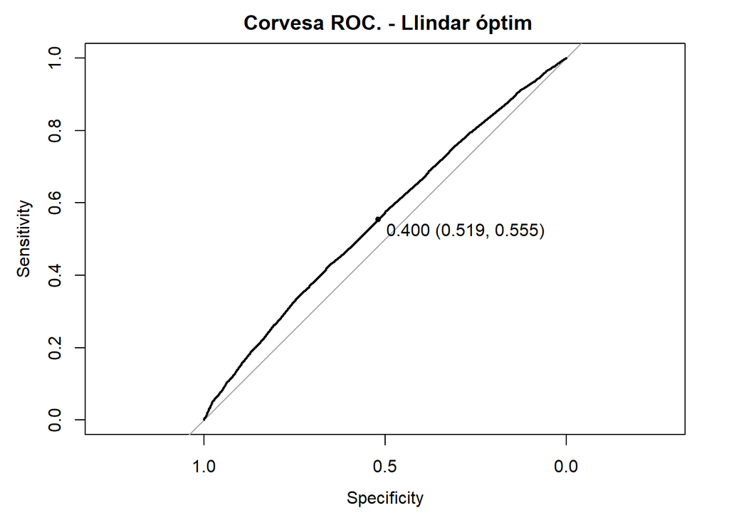

```r
pred=predict(model.recomanancio,data.regressio,type="response")
corba<-roc(data.regressio$recomanar,pred)
graf=plot(corba,print.thres="best", print.thres.best.method="closest.topleft", main=" Corvesa ROC. - Llindar óptim")
```

```r
auc(data.regressio$recomanar, pred)
```

```
## [1] 0.5562195
```

```r
#Anem a ferun regressió logistica per hotel i creant el resultat en forma de taula
llista_hotels=unique(data.hotels_comparables$nomHotel)
result_roc<-NULL
for (cols in llista_hotels)
{

  data.regressio<-data[data$nomHotel==cols,]
  data.regressio$recomanar<-ifelse(data.regressio$notaHotel<data.regressio$notapersona,0,1)

  try(model.recomanacio<-glm(recomanar~TipusHabitacio+Nits+ProcedenciaComentari+TipusViatge+Acompanyament+Season , data = data.regressio),silent=T)
  pred<-predict(model.recomanacio,data.regressio,type="response")
  area<-auc(data.regressio$recomanar, pred)
  optim_point<-optim.thresh(data.regressio$recomanar,pred)$min.ROC.plot.distance
  list.model.recomanacio<-model.recomanacio

  if (is.null(result_roc))
  {
    result_roc<-cbind(cols,area,optim_point,model.recomanacio)

  }
  else
  {
    aux.merge<-cbind(cols,area,optim_point,model.recomanacio)
    result_roc<-rbind(result_roc,aux.merge)

  }


}

# kable(result_roc[,c(1:3)])
```